# Chapter 8 HW

Kishore Prasad

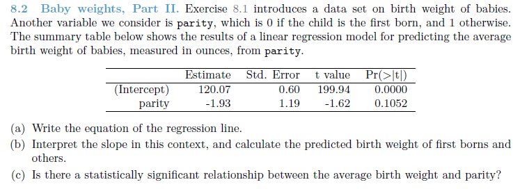

```r
library(ggplot2)
```

The others (with a parity of 1) would be predicted to weigh 118.14 (120.07 - 1.93 $\times$ 1) ounces  
c) A p-value of 0.1052 for parity indicates that there is no statistically significant relationship between average birth weight and parity.

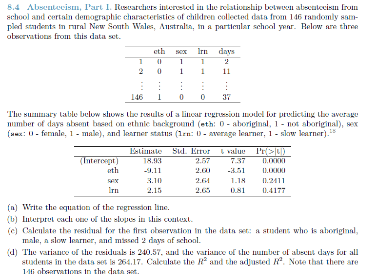

a) The equation for absenteeism is given by:

```r
eth <- 0
sex <- 1
lrn <- 1
actual <- 2

predicted <- 18.93 - 9.11 * eth + 3.1 * sex + 2.15 * lrn
predicted
```

```
## [1] 24.18
```

```r
residual <- actual - predicted
residual
```

```
## [1] -22.18
```

Therefore the residual is -22.18  
d) The following is the calculation:

```r
n <- 146
k <- 3
var_residuals <- 240.57
var_absentdays <- 264.17

R2 <- 1 - (var_residuals / var_absentdays)
R2
```

```
## [1] 0.08933641
```

```r
adjustedR2 <- 1 - (1 - R2) * ( (n-1) / (n-k-1) )
adjustedR2
```

```
## [1] 0.07009704
```

Therefore, $R^2$ = 0.0893364 and adjusted $R^2$ = 0.070097

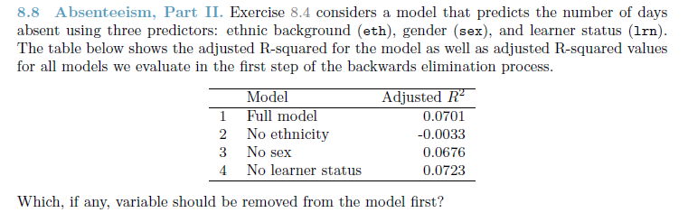

The variable with the highest adjusted $R^2$ is lrn (0.0723). Hence this variable should be removed first.

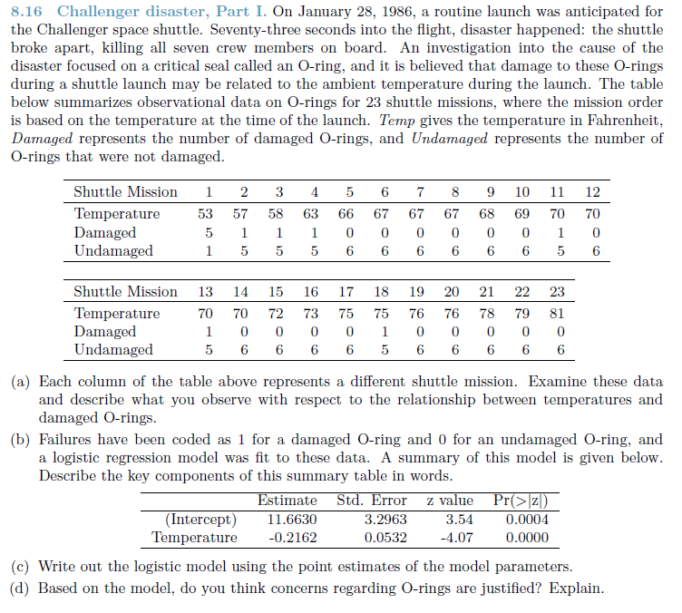

a) Based on a visual inspection of the table, I can find that damages to O-ring is more pronounced for temperatures less than 66 farenheit. There seem to be less damage when the temperature is equal to or above this.  
b) The key components are described as follows:

- Intercept - The intercept estimate of 11.6630 indicates what the failure value will be if the temperature was 0.
- Slope - The slope estimate of -0.2162 indicates that the failure decreases by 0.2162 as the temperature increases by 1 degree.
- The z value and P value help in identifying the strength of the relationship

c) The following is the equation for the logistic regression:

$log_e(\frac{p_i}{1-p_i})$ = 11.6630 - 0.2162 $\times$ $x_{temp}$

d) I would say that the concerns regarding the O-rings are justified. The p-value close to zero.It seems to indicate that O-ring failure is strongly correlated to temperature.

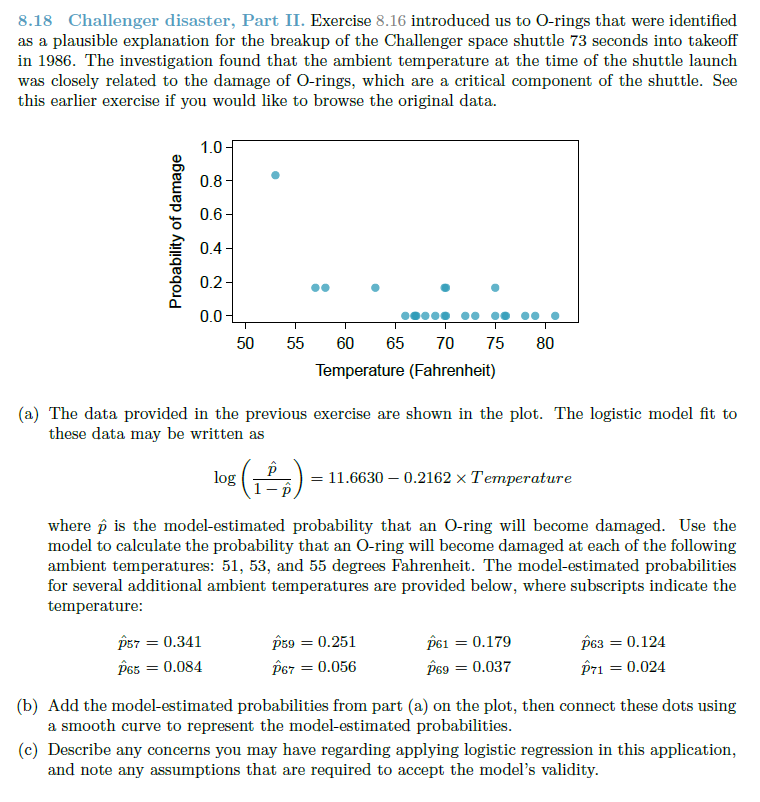

a) The following are the calculations for 51, 53 and 55 degrees:

```r
temp = 51
p51 <- exp(11.6630 - (0.2162 * temp)) / (1 + exp(11.6630 - (0.2162 * temp)))
p51
```

```
## [1] 0.6540297
```

```r
temp = 53
p53 <- exp(11.6630 - (0.2162 * temp)) / (1 + exp(11.6630 - (0.2162 * temp)))
p53
```

```
## [1] 0.5509228
```

```r
temp = 55
p55 <- exp(11.6630 - (0.2162 * temp)) / (1 + exp(11.6630 - (0.2162 * temp)))
p55
```

```
## [1] 0.4432456
```

Therefore the probabilities for 51, 53 and 55 are 0.6540297, 0.5509228 and 0.4432456 respectively.  
b) Lets first create a data frame based on the values provided:

```r
temps <- seq(51, 71, by=2)
probs <- c(p51, p53, p55, 0.341, 0.251, 0.179, 0.124, 0.084, 0.056, 0.037, 0.024)

df_prob <- data.frame(Temperature=temps, Prob_Damage=probs)
```

We now plot the values as a smooth curve:

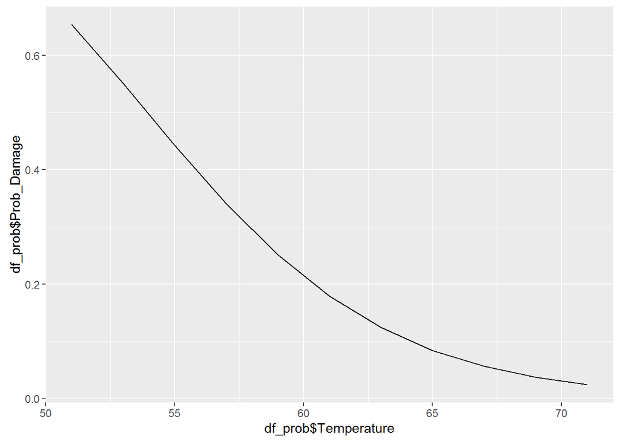

```r
g1 <- ggplot(df_prob) + geom_line(aes(x=df_prob$Temperature, y=df_prob$Prob_Damage ))
g1
```

c) I would say that we do not have sufficient data to learn from a logistic model. The following are the conditions / assumptions for a logistic model:

Conditions/assumptions required for logistic regression model validity include:

Each outcome (Y_i) is independent of the other outcomes. I am assuming that the O-rings are completely replaced for each mission. Given this assumption, I would say that the independence condition is met.